# Lab 1. An Introduction to Pandas and Python

```python
# The %... is an iPython thing, and is not part of the Python language.
# In this case we're just telling the plotting library to draw things on
# the notebook, instead of on a separate window.
%matplotlib inline
#this line above prepares IPython notebook for working with matplotlib

# See all the "as ..." contructs? They're just aliasing the package names.
# That way we can call methods like plt.plot() instead of matplotlib.pyplot.plot().

import numpy as np # imports a fast numerical programming library
import scipy as sp #imports stats functions, amongst other things
import matplotlib as mpl # this actually imports matplotlib
import matplotlib.cm as cm #allows us easy access to colormaps
import matplotlib.pyplot as plt #sets up plotting under plt
import pandas as pd #lets us handle data as dataframes
#sets up pandas table display
pd.set_option('display.width', 500)
pd.set_option('display.max_columns', 100)
pd.set_option('display.notebook_repr_html', True)
import seaborn as sns #sets up styles and gives us more plotting options
```

Python depends on packages for most of its functionality; these can be either built-in (such as sys), or third-party (like all the packages below). Either way you need to import the packages you need before using them.

## The Notebook

Look up http:/www.google.com Lets eat a burrito. $\alpha = \frac{\beta}{\gamma}$

Longer:

$$\alpha = \frac{\beta}{\gamma}$$

1. an item
2. another item
3. i like items

## Pandas

Get Cheatsheet:

from https://drive.google.com/folderview?id=0ByIrJAE4KMTtaGhRcXkxNHhmY2M&usp=sharing

We read in some data from a CSV file. CSV files can be output by any spreadsheet software, and are plain text, so make a great way to share data. This dataset is from Goodreads: i scraped the highest regarded (according to Goodread's proprietary algorithm) books on that site. Ypu'll see how to do such a scraping in the next lab.

```python
df=pd.read_csv("all.csv", header=None,
               names=["rating", 'review_count', 'isbn', 'booktype','author_url', 'year', 'genre_urls', 'dir','rating_count', 'name'],
)
df.head()
```

|  | rating | review_count | isbn | booktype | author_url | year | genre_urls | dir | rating_count | name |
| --- | --- | --- | --- | --- | --- | --- | --- | --- | --- | --- |
| 0 | 4.40 | 136455 | 0439023483 | good_reads:book | https://www.goodreads.com/author/show/153394.S... | 2008 | /genres/young-adult\|/genres/science-fiction\|/g... | dir01/2767052-the-hunger-games.html | 2958974 | The Hunger Games (The Hunger Games, #1) |
| 1 | 4.41 | 16648 | 0439358078 | good_reads:book | https://www.goodreads.com/author/show/1077326.... | 2003 | /genres/fantasy\|/genres/young-adult\|/genres/fi... | dir01/2.Harry_Potter_and_the_Order_of_the_Phoe... | 1284478 | Harry Potter and the Order of the Phoenix (Har... |
| 2 | 3.56 | 85746 | 0316015849 | good_reads:book | https://www.goodreads.com/author/show/941441.S... | 2005 | /genres/young-adult\|/genres/fantasy\|/genres/ro... | dir01/41865.Twilight.html | 2579564 | Twilight (Twilight, #1) |
| 3 | 4.23 | 47906 | 0061120081 | good_reads:book | https://www.goodreads.com/author/show/1825.Har... | 1960 | /genres/classics\|/genres/fiction\|/genres/histo... | dir01/2657.To_Kill_a_Mockingbird.html | 2078123 | To Kill a Mockingbird |
| 4 | 4.23 | 34772 | 0679783261 | good_reads:book | https://www.goodreads.com/author/show/1265.Jan... | 1813 | /genres/classics\|/genres/fiction\|/genres/roman... | dir01/1885.Pride_and_Prejudice.html | 1388992 | Pride and Prejudice |

Notice we have a table! A spreadsheet! And it indexed the rows. Pandas (borrowing from R) calls it a DataFrame. Lets see the types of the columns...

`df`, in python parlance, is an **instance** of the `pd.DataFrame` class, created by calling the `pd.read_csv` function, which cllas the DataFrame constructor inside of it. If you dont understand this sentence, dont worry, it will become clearer later. What you need to take away is that `df` is a dataframe object, and it has **methods**, or functions belonging to it, which allow it to do things. For example `df.head()` is a method that shows the first 5 rows of the dataframe.

[figure not shown]

### The basics

```python
df.dtypes
```

```
rating          float64
review_count     object
isbn             object
booktype         object
author_url       object
year            float64
genre_urls       object
dir              object
rating_count     object
name             object
dtype: object
```

The shape of the object is:

```python
df.shape
```

```
(6000, 10)
```

6000 rows times 10 columns. A spredsheet is a table is a matrix. How can we access members of this **tuple** (brackets like so:() )

```python
df.shape[0], df.shape[1]
```

```
(6000, 10)
```

These are the column names.

```python
df.columns
```

```
Index([u'rating', u'review_count', u'isbn', u'booktype', u'author_url', u'year', u'genre_urls', u'dir', u'rating_count', u'name'], dtype='object')
```

As the diagram above shows, pandas considers a table (dataframe) as a pasting of many "series" together, horizontally.

```python
type(df.rating), type(df)
```

```
(pandas.core.series.Series, pandas.core.frame.DataFrame)
```

### Querying

A spreadsheet is useless if you cant dice/sort/etc it. Here we look for all books with a rating less than 3.

```python
df.rating < 3
```

```
0       False
1       False
2       False
3       False
4       False
5       False
6       False
7       False
8       False
9       False
10      False
11      False
12      False
13      False
14      False
```

[output cut: 47 more lines]

This gives us `True`s and `False`s. Such a series is called a mask. If we count the number of `True`s, and divide by the total, we'll get the fraction of ratings $\lt$ 3. To do this numerically see this:

```python
np.sum(df.rating < 3)
```

```
4
```

Why did that work?

```python
print 1*True, 1*False
```

```
1 0
```

So we ought to be able to do this

```python
np.sum(df.rating < 3)/df.shape[0]
```

```
0
```

But we get a 0? Why? In Python 2.x division is **integer division** by default. So one can fix by converting the `df.shape[0]` to a float

```python
np.sum(df.rating < 3)/float(df.shape[0])
```

```
0.00066666666666666664
```

Notice that you could just find the average since the `True`s map to 1s.

```python
np.mean(df.rating < 3.0)
```

```
0.00066666666666666664
```

Or directly, in Pandas, which works since `df.rating < 3` is a pandas Series.

```python
(df.rating < 3).mean()
```

```
0.00066666666666666664
```

### Filtering

Here are two ways to get a filtered dataframe

```python
df.query("rating > 4.5")
```

|  | rating | review_count | isbn | booktype | author_url | year | genre_urls | dir | rating_count | name |
| --- | --- | --- | --- | --- | --- | --- | --- | --- | --- | --- |
| 17 | 4.58 | 1314 | 0345538374 | good_reads:book | https://www.goodreads.com/author/show/656983.J... | 1973 | /genres/fantasy\|/genres/classics\|/genres/scien... | dir01/30.J_R_R_Tolkien_4_Book_Boxed_Set.html | 68495 | J.R.R. Tolkien 4-Book Boxed Set |
| 162 | 4.55 | 15777 | 075640407X | good_reads:book | https://www.goodreads.com/author/show/108424.P... | 2007 | /genres/fantasy\|/genres/fiction | dir02/186074.The_Name_of_the_Wind.html | 210018 | The Name of the Wind (The Kingkiller Chronicle... |
| 222 | 4.53 | 15256 | 055357342X | good_reads:book | https://www.goodreads.com/author/show/346732.G... | 2000 | /genres/fantasy\|/genres/fiction\|/genres/fantas... | dir03/62291.A_Storm_of_Swords.html | 327992 | A Storm of Swords (A Song of Ice and Fire, #3) |
| 242 | 4.53 | 5404 | 0545265355 | good_reads:book | https://www.goodreads.com/author/show/153394.S... | 2010 | /genres/young-adult\|/genres/fiction\|/genres/fa... | dir03/7938275-the-hunger-games-trilogy-boxset.... | 102330 | The Hunger Games Trilogy Boxset (The Hunger Ga... |
| 249 | 4.80 | 644 | 0740748475 | good_reads:book | https://www.goodreads.com/author/show/13778.Bi... | 2005 | /genres/sequential-art\|/genres/comics\|/genres/... | dir03/24812.The_Complete_Calvin_and_Hobbes.html | 22674 | The Complete Calvin and Hobbes |
| 284 | 4.58 | 15195 | 1406321346 | good_reads:book | https://www.goodreads.com/author/show/150038.C... | 2013 | /genres/fantasy\|/genres/young-adult\|/genres/fa... | dir03/18335634-clockwork-princess.html | 130161 | Clockwork Princess (The Infernal Devices, #3) |
| 304 | 4.54 | 572 | 0140259449 | good_reads:book | https://www.goodreads.com/author/show/1265.Jan... | 1933 | /genres/classics\|/genres/fiction\|/genres/roman... | dir04/14905.The_Complete_Novels.html | 17539 | The Complete Novels |
| 386 | 4.55 | 8820 | 0756404738 | good_reads:book | https://www.goodreads.com/author/show/108424.P... | 2011 | /genres/fantasy\|/genres/fantasy\|/genres/epic-f... | dir04/1215032.The_Wise_Man_s_Fear.html | 142499 | The Wise Man's Fear (The Kingkiller Chronicle,... |
| 400 | 4.53 | 9292 | 1423140605 | good_reads:book | https://www.goodreads.com/author/show/15872.Ri... | 2012 | /genres/fantasy\|/genres/young-adult\|/genres/fa... | dir05/12127750-the-mark-of-athena.html | 128412 | The Mark of Athena (The Heroes of Olympus, #3) |
| 475 | 4.57 | 824 | 1416997857 | good_reads:book | https://www.goodreads.com/author/show/150038.C... | 2009 | /genres/fantasy\|/genres/young-adult\|/genres/fa... | dir05/6485421-the-mortal-instruments-boxed-set... | 39720 | The Mortal Instruments Boxed Set (The Mortal I... |
| 483 | 4.59 | 2622 | 0312362153 | good_reads:book | https://www.goodreads.com/author/show/4430.She... | 2008 | /genres/romance\|/genres/paranormal-romance\|/ge... | dir05/2299110.Acheron.html | 35028 | Acheron (Dark-Hunter, #8) |
| 554 | 4.54 | 4809 | 0385341679 | good_reads:book | https://www.goodreads.com/author/show/48206.Ka... | 2011 | /genres/fantasy\|/genres/urban-fantasy\|/genres/... | dir06/7304203-shadowfever.html | 52812 | Shadowfever (Fever, #5) |
| 577 | 4.60 | 5732 | 0765326353 | good_reads:book | https://www.goodreads.com/author/show/38550.Br... | 2010 | /genres/science-fiction-fantasy\|/genres/fantas... | dir06/7235533-the-way-of-kings.html | 76551 | The Way of Kings (The Stormlight Archive, #1) |
| 620 | 4.54 | 7767 | 1423146727 | good_reads:book | https://www.goodreads.com/author/show/15872.Ri... | 2013 | /genres/fantasy\|/genres/young-adult\|/genres/fa... | dir07/12127810-the-house-of-hades.html | 72082 | The House of Hades (The Heroes of Olympus, #4) |
| 840 | 4.57 | 431 | 1423113497 | good_reads:book | https://www.goodreads.com/author/show/15872.Ri... | 2008 | /genres/fantasy\|/genres/young-adult\|/genres/fa... | dir09/3165162-percy-jackson-and-the-olympians-... | 22937 | Percy Jackson and the Olympians Boxed Set (Per... |
| 883 | 4.58 | 558 | 0140286802 | good_reads:book | https://www.goodreads.com/author/show/500.Jorg... | 1998 | /genres/short-stories\|/genres/literature\|/genr... | dir09/17961.Collected_Fictions.html | 12596 | Collected Fictions |
| 911 | 4.85 | 26 | 1491732954 | good_reads:book | https://www.goodreads.com/author/show/8189303.... | 2014 | /genres/fiction | dir10/22242097-honor-and-polygamy.html | 97 | Honor and Polygamy |
| 935 | 4.64 | 148 | 1595142711 | good_reads:book | https://www.goodreads.com/author/show/137902.R... | 2009 | /genres/paranormal\|/genres/vampires\|/genres/yo... | dir10/6339989-vampire-academy-collection.html | 21743 | Vampire Academy Collection (Vampire Academy, #... |
| 938 | 4.51 | 11011 | 1481426303 | good_reads:book | https://www.goodreads.com/author/show/150038.C... | 2014 | /genres/fantasy\|/genres/young-adult\|/genres/fa... | dir10/8755785-city-of-heavenly-fire.html | 69924 | City of Heavenly Fire (The Mortal Instruments,... |
| 953 | 4.56 | 27 | 1477276068 | good_reads:book | https://www.goodreads.com/author/show/6621980.... | 2012 | NaN | dir10/16243767-crossing-the-seas.html | 90 | Crossing the Seas |
| 958 | 4.57 | 38199 | 0545010225 | good_reads:book | https://www.goodreads.com/author/show/1077326.... | 2007 | /genres/fantasy\|/genres/young-adult\|/genres/fa... | dir10/136251.Harry_Potter_and_the_Deathly_Hall... | 1245866 | Harry Potter and the Deathly Hallows (Harry Po... |
| 1033 | 4.56 | 1304 | 0007119550 | good_reads:book | https://www.goodreads.com/author/show/346732.G... | 2000 | /genres/fiction\|/genres/fantasy\|/genres/epic-f... | dir11/147915.A_Storm_of_Swords.html | 41161 | A Storm of Swords (A Song of Ice and Fire, #3-2) |
| 1109 | 4.70 | 23 | NaN | good_reads:book | https://www.goodreads.com/author/show/7488658.... | 2013 | /genres/romance | dir12/19181419-a-bird-without-wings.html | 56 | A Bird Without Wings |
| 1127 | 4.52 | 644 | 0141183047 | good_reads:book | https://www.goodreads.com/author/show/7816.Fer... | 1982 | /genres/poetry\|/genres/fiction\|/genres/philoso... | dir12/45974.The_Book_of_Disquiet.html | 7463 | The Book of Disquiet |
| 1151 | 4.64 | 84 | 1491877928 | good_reads:book | https://www.goodreads.com/author/show/7271860.... | 2013 | /genres/war\|/genres/historical-fiction\|/genres... | dir12/18501652-the-guardian-of-secrets-and-her... | 167 | The Guardian of Secrets and Her Deathly Pact |
| 1186 | 4.51 | 4853 | 1619630621 | good_reads:book | https://www.goodreads.com/author/show/3433047.... | 2013 | /genres/fantasy\|/genres/young-adult\|/genres/ro... | dir12/17167166-crown-of-midnight.html | 34142 | Crown of Midnight (Throne of Glass, #2) |
| 1202 | 4.59 | 1260 | 0310902711 | good_reads:book | https://www.goodreads.com/author/show/5158478.... | 1972 | /genres/religion\|/genres/christian\|/genres/non... | dir13/280111.Holy_Bible.html | 25584 | Holy Bible |
| 1260 | 4.60 | 1943 | 0842377506 | good_reads:book | https://www.goodreads.com/author/show/6492.Fra... | 1993 | /genres/christian-fiction\|/genres/historical-f... | dir13/95617.A_Voice_in_the_Wind.html | 37923 | A Voice in the Wind (Mark of the Lion, #1) |
| 1268 | 4.52 | 215 | 1557091528 | good_reads:book | https://www.goodreads.com/author/show/63859.Ja... | 1787 | /genres/history\|/genres/non-fiction\|/genres/po... | dir13/89959.The_Constitution_of_the_United_Sta... | 12894 | The Constitution of the United States of America |
| 1300 | 4.61 | 24 | 1499227299 | good_reads:book | https://www.goodreads.com/author/show/7414345.... | 2014 | /genres/paranormal\|/genres/vampires\|/genres/pa... | dir14/22090082-vampire-princess-rising.html | 128 | Vampire Princess Rising (The Winters Family Sa... |
| ... | ... | ... | ... | ... | ... | ... | ... | ... | ... | ... |
| 5532 | 4.86 | 4 | 1477504540 | good_reads:book | https://www.goodreads.com/author/show/5989528.... | 2013 | NaN | dir56/17695243-call-of-the-lost-ages.html | 7 | Call Of The Lost Ages |
| 5549 | 4.62 | 13 | 0882408704 | good_reads:book | https://www.goodreads.com/author/show/947.Will... | 1899 | /genres/classics\|/genres/fiction\|/genres/poetr... | dir56/17134346-the-complete-works-of-william-s... | 217 | The Complete Works of William Shakespeare |
| 5557 | 4.61 | 14 | NaN | good_reads:book | https://www.goodreads.com/author/show/32401.Al... | 2006 | /genres/fantasy\|/genres/young-adult | dir56/13488552-the-books-of-pellinor.html | 394 | The Books of Pellinor |
| 5563 | 4.70 | 30 | NaN | good_reads:book | https://www.goodreads.com/author/show/7153266.... | 2014 | /genres/childrens | dir56/20445451-children-s-book.html | 57 | Children's book |
| 5564 | 5.00 | 9 | NaN | good_reads:book | https://www.goodreads.com/author/show/7738947.... | 2014 | /genres/romance\|/genres/new-adult | dir56/21902777-untainted.html | 14 | Untainted (Photographer Trilogy, #3) |
| 5584 | 4.75 | 3 | 1481959824 | good_reads:book | https://www.goodreads.com/author/show/5100743.... | 2013 | NaN | dir56/17606460-why-not-world.html | 8 | Why Not-World |
| 5588 | 4.66 | 190 | NaN | good_reads:book | https://www.goodreads.com/author/show/4942228.... | 2011 | /genres/romance\|/genres/m-m-romance\|/genres/sc... | dir56/11737700-fade.html | 996 | Fade (In the company of shadows, #4) |
| 5591 | 4.58 | 31 | 1500118680 | good_reads:book | https://www.goodreads.com/author/show/7738947.... | 2014 | /genres/romance\|/genres/new-adult | dir56/22023804-logan-s-story.html | 45 | Logan's Story (Sand & Clay, #0.5) |
| 5601 | 4.66 | 312 | 0842384898 | good_reads:book | https://www.goodreads.com/author/show/5158478.... | 1902 | /genres/christian\|/genres/religion\|/genres/non... | dir57/930470.Holy_Bible.html | 2666 | Holy Bible |
| 5607 | 4.66 | 513 | 0007444397 | good_reads:book | https://www.goodreads.com/author/show/4659154.... | 2011 | /genres/non-fiction\|/genres/biography | dir57/11792612-dare-to-dream.html | 5572 | Dare to Dream (100% Official) |
| 5619 | 4.52 | 462 | 0991190920 | good_reads:book | https://www.goodreads.com/author/show/7092218.... | 2014 | /genres/fantasy\|/genres/paranormal\|/genres/fai... | dir57/18188649-escaping-destiny.html | 3795 | Escaping Destiny (The Fae Chronicles, #3) |
| 5635 | 4.54 | 958 | 0778315703 | good_reads:book | https://www.goodreads.com/author/show/4480131.... | 2013 | /genres/erotica\|/genres/bdsm\|/genres/adult-fic... | dir57/17251444-the-mistress.html | 4869 | The Mistress (The Original Sinners, #4) |
| 5642 | 4.70 | 158 | 1417642165 | good_reads:book | https://www.goodreads.com/author/show/13778.Bi... | 1992 | /genres/sequential-art\|/genres/comics\|/genres/... | dir57/70487.Calvin_and_Hobbes.html | 9224 | Calvin and Hobbes |
| 5657 | 4.80 | 8 | 1469908530 | good_reads:book | https://www.goodreads.com/author/show/4695431.... | 2012 | /genres/fantasy | dir57/15734769-myrtle-mae-and-the-mirror-in-th... | 10 | Myrtle Mae and the Mirror in the Attic (The Ma... |
| 5665 | 4.53 | 61 | NaN | good_reads:book | https://www.goodreads.com/author/show/7738947.... | 2014 | /genres/romance\|/genres/new-adult\|/genres/myst... | dir57/20975446-tainted-pictures.html | 103 | Tainted Pictures (Photographer Trilogy, #2) |
| 5683 | 4.56 | 204 | NaN | good_reads:book | https://www.goodreads.com/author/show/3097905.... | NaN | /genres/fantasy\|/genres/young-adult\|/genres/ro... | dir57/12474623-tiger-s-dream.html | 895 | Tiger's Dream (The Tiger Saga, #5) |
| 5692 | 5.00 | 0 | NaN | good_reads:book | https://www.goodreads.com/author/show/5989528.... | 2012 | NaN | dir57/14288412-abstraction-in-theory---laws-of... | 6 | Abstraction In Theory - Laws Of Physical Trans... |
| 5716 | 4.67 | 34 | 0810117134 | good_reads:book | https://www.goodreads.com/author/show/205563.M... | 1970 | /genres/classics\|/genres/fiction\|/genres/histo... | dir58/1679497.The_Fortress.html | 1335 | The Fortress |
| 5717 | 4.71 | 4 | NaN | good_reads:book | https://www.goodreads.com/author/show/5838022.... | 2012 | NaN | dir58/13741511-american-amaranth.html | 14 | American Amaranth |
| 5718 | 4.60 | 656 | 1613725132 | good_reads:book | https://www.goodreads.com/author/show/1122775.... | 2012 | /genres/romance\|/genres/m-m-romance\|/genres/ro... | dir58/13246997-armed-dangerous.html | 5268 | Armed & Dangerous (Cut & Run, #5) |
| 5726 | 4.55 | 106 | 1594170347 | good_reads:book | https://www.goodreads.com/author/show/5158478.... | 1952 | /genres/religion\|/genres/reference\|/genres/rel... | dir58/147635.Holy_Bible.html | 1750 | Holy Bible |
| 5729 | 4.83 | 16 | NaN | good_reads:book | https://www.goodreads.com/author/show/7058502.... | 2014 | NaN | dir58/22312293-the-keeper.html | 29 | The Keeper (The Keeper, #5) |
| 5753 | 4.61 | 811 | 1937551865 | good_reads:book | https://www.goodreads.com/author/show/1122775.... | 2013 | /genres/romance\|/genres/m-m-romance\|/genres/ro... | dir58/16159276-touch-geaux.html | 4212 | Touch & Geaux (Cut & Run, #7) |
| 5764 | 4.54 | 228 | NaN | good_reads:book | https://www.goodreads.com/author/show/2112402.... | 2013 | /genres/non-fiction\|/genres/self-help\|/genres/... | dir58/18479831-staying-strong.html | 2343 | Staying Strong |
| 5778 | 4.63 | 0 | NaN | good_reads:book | https://www.goodreads.com/author/show/4808225.... | 2010 | NaN | dir58/11187937-un-spoken.html | 19 | (Un) Spoken |
| 5806 | 4.57 | 121 | 0679777458 | good_reads:book | https://www.goodreads.com/author/show/8361.Dor... | 1966 | /genres/historical-fiction\|/genres/fiction\|/ge... | dir59/351211.The_Disorderly_Knights.html | 2177 | The Disorderly Knights (The Lymond Chronicles,... |
| 5873 | 4.55 | 103 | 144247372X | good_reads:book | https://www.goodreads.com/author/show/2876763.... | 2012 | /genres/fantasy\|/genres/paranormal\|/genres/ang... | dir59/14367071-the-complete-hush-hush-saga.html | 2869 | The Complete Hush, Hush Saga |
| 5874 | 4.78 | 18 | 2851944371 | good_reads:book | https://www.goodreads.com/author/show/318835.O... | 1972 | /genres/poetry\|/genres/fiction\|/genres/nobel-p... | dir59/2014000.Le_Monogramme.html | 565 | Le Monogramme |
| 5880 | 4.61 | 123 | NaN | good_reads:book | https://www.goodreads.com/author/show/4942228.... | 2010 | /genres/romance\|/genres/m-m-romance\|/genres/sc... | dir59/10506860-the-interludes.html | 1031 | The Interludes (In the company of shadows, #3) |
| 5957 | 4.72 | 104 | 178048044X | good_reads:book | https://www.goodreads.com/author/show/20248.J_... | 2010 | /genres/romance\|/genres/paranormal\|/genres/vam... | dir60/10780042-j-r-ward-collection.html | 1788 | J. R. Ward Collection |

224 rows × 10 columns

Here we create a mask and use it to "index" into the dataframe to get the rows we want.

```python
df[df.year < 0]
```

[output not shown]

If you want to combine these conditions, use the second form and put '()' brackets around each condition. The query uses a boolean AND. Each condition ceates a mask of trues and falses.

```python
df[(df.year < 0) & (df.rating > 4)]#there were none greater than 4.5!
```

|  | rating | review_count | isbn | booktype | author_url | year | genre_urls | dir | rating_count | name |
| --- | --- | --- | --- | --- | --- | --- | --- | --- | --- | --- |
| 246 | 4.01 | 365 | 0147712556 | good_reads:book | https://www.goodreads.com/author/show/903.Homer | -800 | /genres/classics\|/genres/fantasy\|/genres/mytho... | dir03/1375.The_Iliad_The_Odyssey.html | 35123 | The Iliad/The Odyssey |
| 746 | 4.06 | 1087 | 0140449183 | good_reads:book | https://www.goodreads.com/author/show/5158478.... | -500 | /genres/classics\|/genres/spirituality\|/genres/... | dir08/99944.The_Bhagavad_Gita.html | 31634 | The Bhagavad Gita |
| 1397 | 4.03 | 890 | 0192840509 | good_reads:book | https://www.goodreads.com/author/show/12452.Aesop | -560 | /genres/classics\|/genres/childrens\|/genres/lit... | dir14/21348.Aesop_s_Fables.html | 71259 | Aesop's Fables |
| 1882 | 4.02 | 377 | 0872205541 | good_reads:book | https://www.goodreads.com/author/show/879.Plato | -400 | /genres/philosophy\|/genres/classics\|/genres/no... | dir19/22632.The_Trial_and_Death_of_Socrates.html | 18712 | The Trial and Death of Socrates |
| 3133 | 4.30 | 131 | 0872203492 | good_reads:book | https://www.goodreads.com/author/show/879.Plato | -400 | /genres/philosophy\|/genres/classics\|/genres/no... | dir32/9462.Complete_Works.html | 7454 | Complete Works |
| 4475 | 4.11 | 281 | 0865163480 | good_reads:book | https://www.goodreads.com/author/show/879.Plato | -390 | /genres/philosophy\|/genres/classics\|/genres/no... | dir45/73945.Apology.html | 11478 | Apology |
| 5367 | 4.07 | 133 | 0872206335 | good_reads:book | https://www.goodreads.com/author/show/879.Plato | -360 | /genres/philosophy\|/genres/classics\|/genres/no... | dir54/30292.Five_Dialogues.html | 9964 | Five Dialogues |

### Cleaning

We first check the datatypes. Notice that `review_count`, `rating_count` are of type `object` (which means they are either strings or Pandas couldnt figure what they are), while `year` is a float.

```python
df.dtypes
```

```
rating          float64
review_count     object
isbn             object
booktype         object
author_url       object
year            float64
genre_urls       object
dir              object
rating_count     object
name             object
dtype: object
```

Suppose we try and fix this

```python
df['rating_count']=df.rating_count.astype(int)
df['review_count']=df.review_count.astype(int)
df['year']=df.year.astype(int)
```

```
---------------------------------------------------------------------------
ValueError                                Traceback (most recent call last)
<ipython-input-21-8bf38ae9d108> in <module>()
----> 1 df['rating_count']=df.rating_count.astype(int)
      2 df['review_count']=df.review_count.astype(int)
      3 df['year']=df.year.astype(int)

//anaconda/lib/python2.7/site-packages/pandas/core/generic.pyc in astype(self, dtype, copy, raise_on_error, **kwargs)
   2409
   2410         mgr = self._data.astype(
-> 2411             dtype=dtype, copy=copy, raise_on_error=raise_on_error, **kwargs)
   2412         return self._constructor(mgr).__finalize__(self)
   2413

//anaconda/lib/python2.7/site-packages/pandas/core/internals.pyc in astype(self, dtype, **kwargs)
   2502
   2503     def astype(self, dtype, **kwargs):
-> 2504         return self.apply('astype', dtype=dtype, **kwargs)
   2505
   2506     def convert(self, **kwargs):

//anaconda/lib/python2.7/site-packages/pandas/core/internals.pyc in apply(self, f, axes, filter, do_integrity_check, **kwargs)
   2457                                                  copy=align_copy)
   2458
-> 2459             applied = getattr(b, f)(**kwargs)
   2460
   2461             if isinstance(applied, list):

//anaconda/lib/python2.7/site-packages/pandas/core/internals.pyc in astype(self, dtype, copy, raise_on_error, values, **kwargs)
    371     def astype(self, dtype, copy=False, raise_on_error=True, values=None, **kwargs):
    372         return self._astype(dtype, copy=copy, raise_on_error=raise_on_error,
--> 373                             values=values, **kwargs)
    374
    375     def _astype(self, dtype, copy=False, raise_on_error=True, values=None,

//anaconda/lib/python2.7/site-packages/pandas/core/internals.pyc in _astype(self, dtype, copy, raise_on_error, values, klass, **kwargs)
    401             if values is None:
    402                 # _astype_nansafe works fine with 1-d only
--> 403                 values = com._astype_nansafe(self.values.ravel(), dtype, copy=True)
    404                 values = values.reshape(self.values.shape)
    405             newb = make_block(values,

//anaconda/lib/python2.7/site-packages/pandas/core/common.pyc in _astype_nansafe(arr, dtype, copy)
   2729     elif arr.dtype == np.object_ and np.issubdtype(dtype.type, np.integer):
   2730         # work around NumPy brokenness, #1987
-> 2731         return lib.astype_intsafe(arr.ravel(), dtype).reshape(arr.shape)
   2732
   2733     if copy:

pandas/lib.pyx in pandas.lib.astype_intsafe (pandas/lib.c:14844)()

pandas/src/util.pxd in util.set_value_at (pandas/lib.c:63086)()

ValueError: invalid literal for long() with base 10: 'None'
```

Oppos we got an error. Something is not right. Its trying to convert some python datatype: `None` into an int. This usually means data was missing. Was it?

```python
df[df.year.isnull()]
```

|  | rating | review_count | isbn | booktype | author_url | year | genre_urls | dir | rating_count | name |
| --- | --- | --- | --- | --- | --- | --- | --- | --- | --- | --- |
| 2442 | 4.23 | 526 |  | good_reads:book | https://www.goodreads.com/author/show/623606.A... | NaN | /genres/religion\|/genres/islam\|/genres/non-fic... | dir25/1301625.La_Tahzan.html | 4134 | La Tahzan |
| 2869 | 4.61 | 2 |  | good_reads:book | https://www.goodreads.com/author/show/8182217.... | NaN |  | dir29/22031070-my-death-experiences---a-preach... | 23 | My Death Experiences - A Preacherâs 18 Apoca... |
| 3643 | NaN | None | None | None | None | NaN |  | dir37/9658936-harry-potter.html | None | None |
| 5282 | NaN | None | None | None | None | NaN |  | dir53/113138.The_Winner.html | None | None |
| 5572 | 3.71 | 35 | 8423336603 | good_reads:book | https://www.goodreads.com/author/show/285658.E... | NaN | /genres/fiction | dir56/890680._rase_una_vez_el_amor_pero_tuve_q... | 403 | Ãrase una vez el amor pero tuve que matarlo. ... |
| 5658 | 4.32 | 44 |  | good_reads:book | https://www.goodreads.com/author/show/25307.Ro... | NaN | /genres/fantasy\|/genres/fantasy\|/genres/epic-f... | dir57/5533041-assassin-s-apprentice-royal-assa... | 3850 | Assassin's Apprentice / Royal Assassin (Farsee... |
| 5683 | 4.56 | 204 |  | good_reads:book | https://www.goodreads.com/author/show/3097905.... | NaN | /genres/fantasy\|/genres/young-adult\|/genres/ro... | dir57/12474623-tiger-s-dream.html | 895 | Tiger's Dream (The Tiger Saga, #5) |

Aha, we had some incomplete data. Lets get rid of it

```python
df = df[df.year.notnull()]
df.shape
```

```
(5993, 10)
```

We removed those 7 rows. Lets try the type conversion again

```python
df['rating_count']=df.rating_count.astype(int)
df['review_count']=df.review_count.astype(int)
df['year']=df.year.astype(int)
```

```python
df.dtypes
```

```
rating          float64
review_count      int64
isbn             object
booktype         object
author_url       object
year              int64
genre_urls       object
dir              object
rating_count      int64
name             object
dtype: object
```

Much cleaner now!

### Visualizing

Pandas has handy built in visualization.

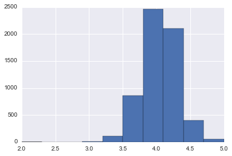

```python
df.rating.hist();
```

We can do this in more detail, plotting against a mean, with cutom binsize or number of bins. Note how to label axes and create legends.

```
4.04220073358 4.04220073358 4.05
```

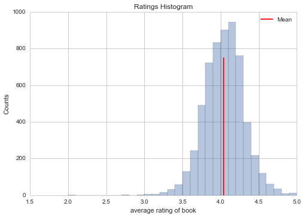

```python
sns.set_context("notebook")
meanrat=df.rating.mean()
#you can get means and medians in different ways
print meanrat, np.mean(df.rating), df.rating.median()
with sns.axes_style("whitegrid"):
    df.rating.hist(bins=30, alpha=0.4);
    plt.axvline(meanrat, 0, 0.75, color='r', label='Mean')
    plt.xlabel("average rating of book")
    plt.ylabel("Counts")
    plt.title("Ratings Histogram")
    plt.legend()
    #sns.despine()
```

One can see the sparseness of review counts. This will be important when we learn about recommendations: we'll have to *regularize* our models to deal with it.

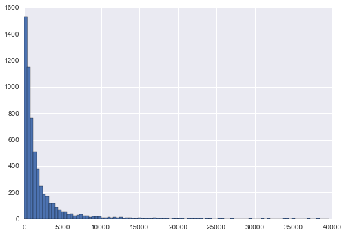

```python
df.review_count.hist(bins=np.arange(0, 40000, 400))
```

The structure may be easier to see if we rescale the x-axis to be logarithmic.

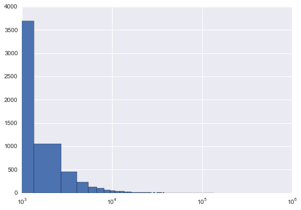

```python
df.review_count.hist(bins=100)
plt.xscale("log");
```

Here we make a scatterplot in matplotlib of rating against year. By setting the alpha transparency low we can how the density of highly rated books on goodreads has changed.

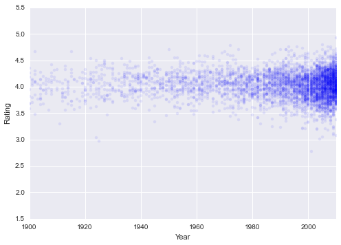

```python
plt.scatter(df.year, df.rating, lw=0, alpha=.08)
plt.xlim([1900,2010])
plt.xlabel("Year")
plt.ylabel("Rating")
```

### Pythons and ducks

Notice that we used the series in the x-list and y-list slots in the `scatter` function in the `plt` module.

In working with python I always remember: a python is a duck.

What I mean is, python has a certain way of doing things. For example lets call one of these ways listiness. Listiness works on lists, dictionaries, files, and a general notion of something called an iterator.

A Pandas series plays like a python list:

```python
alist=[1,2,3,4,5]
```

We can construct another list by using the syntax below, also called a list comprehension.

```python
asquaredlist=[i*i for i in alist]
asquaredlist
```

```
[1, 4, 9, 16, 25]
```

And then we can again make a scatterplot

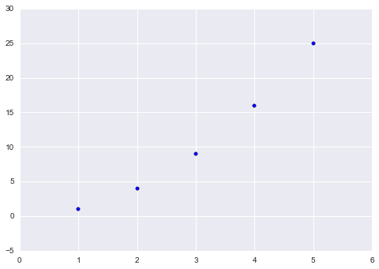

```python
plt.scatter(alist, asquaredlist);
```

```python
print type(alist)
```

```
<type 'list'>
```

In other words, something is a duck if it quacks like a duck. A Pandas series quacks like a python list. They both support something called the iterator protocol, an notion of behaving in a "listy" way. And Python functions like `plt.scatter` will accept anything that behaves listy. Indeed here's one more example:

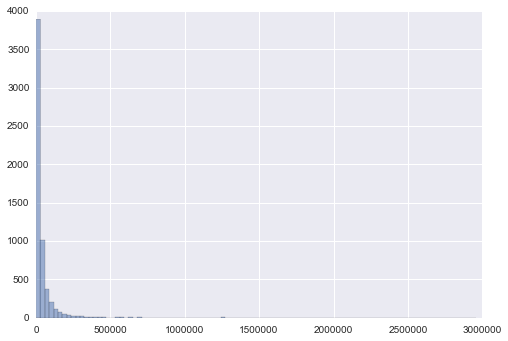

```python
plt.hist(df.rating_count.values, bins=100, alpha=0.5);
```

```python
print type(df.rating_count), type(df.rating_count.values)
```

```
<class 'pandas.core.series.Series'> <type 'numpy.ndarray'>
```

Series and numpy lists behave similarly as well.

### Vectorization

Numpy arrays are a bit different from regular python lists, and are the bread and butter of data science. Pandas Series are built atop them.

```python
alist + alist
```

```
[1, 2, 3, 4, 5, 1, 2, 3, 4, 5]
```

```python
np.array(alist)
```

```
array([1, 2, 3, 4, 5])
```

```python
np.array(alist)+np.array(alist)
```

```
array([ 2,  4,  6,  8, 10])
```

```python
np.array(alist)**2
```

```
array([ 1,  4,  9, 16, 25])
```

In other words, operations on numpy arrays, and by extension, Pandas Series, are **vectorized**. You can add two numpy lists by just using `+` whereas the result isnt what you might expect for regular python lists. To add regular python lists elementwise, you will need to use a loop:

```python
newlist=[]
for item in alist:
    newlist.append(item+item)
newlist
```

```
[2, 4, 6, 8, 10]
```

**Vectorization** is a powerful idiom, and we will use it a lot in this class. And, for almost all data intensive computing, we will use numpy arrays rather than python lists, as the python numerical stack is based on it.

You have seen this in idea in spreadsheets where you add an entire column to another one.

Two final examples

```python
a=np.array([1,2,3,4,5])
print type(a)
b=np.array([1,2,3,4,5])

print a*b
```

```
<type 'numpy.ndarray'>
[ 1  4  9 16 25]
```

```python
a+1
```

```
array([2, 3, 4, 5, 6])
```